# Temporal disease progress: Linear and non-linear regression models

Mladen Cucak; Felipe Dalla Lana; Mauricio Serrano; Paul Esker, Miranda DePriest

# **Introduction**

After illustrating the use of if else statements in manipulating our R session, we will learn about linear regression. Linear regression is a method of plotting a response variable in a straight line. We’ll address the conditions needed for using this technique and see how to evaluate how well the resulting linear model fits the data.

Then we’ll explore several different methods of nonlinear regression. This is a type of modeling that can be used when the response variable doesn’t have a linear trajectory. Just like with linear regression, we’ll talk about the assumptions and methods of evaluation for these kinds of methods too.

# **Getting started**

We will load in all of the necessary packages. Some packages may be unfamiliar, so there are comments next to them explaining why we need them. Labeling packages like this can be helpful for remembering why we need certain packages, or why we might not need them if we adapt the script for some other purpose.

While you’re looking at the notes left for many of the packages, think about why commenting on your code is helpful. What kind of comments could help you understand this lesson, or your own R project, in the future? How could your comments help another person understand what you’ve done? Commenting to explain your code is a crucial part of ensuring your work is reproducible.

```r
# We'll create the list of needed packages
list.of.packages <-
  c("tidyverse",
    "rmarkdown",
    "gt", # package for customizing html table view
    "DT", # similar as above
    "kableExtra", # Another package for html table customization
    "rcompanion", # Useful tool for summarizing model outputs and several other modeling related tasks
    "conflicted", #Some functions are named the same way across different packages and they can be conflicts and this package helps sorting this problem
    "here", #helps with the reproducibility across operating systems
    "ggResidpanel", # Diagnostic plots for several models
    "shiny", # Package for visualization
    "shinythemes",
    "shinydashboard",
    "shinyscreenshot", #capture screenshots
    "minpack.lm", # Fitting non-linear models
    "deSolve" # Solvers for Initial Value Problems of Differential Equations
  )

# Check for any packages that haven't been downloaded yet
new.packages <-
  list.of.packages[!(list.of.packages %in% installed.packages()[, "Package"])]

# Download packages that are not already present in the library
if (length(new.packages))
  install.packages(new.packages)

# Load packages
packages_load <-
  lapply(list.of.packages, require, character.only = TRUE)

#Print warning if there is a problem with installing/loading some of packages
if (any(as.numeric(packages_load) == 0)) {
  warning(paste("Package/s: ", paste(list.of.packages[packages_load != TRUE], sep = ", "), "not loaded!"))
} else {
  print("All packages were successfully loaded.")
}
```

```
## [1] "All packages were successfully loaded."
```

```r
# And clear the various package-related objects from the Global Environment
rm(list.of.packages, new.packages, packages_load)

#Resolve conflicts between identical functions from different packages
  conflict_prefer("filter", "dplyr")
  conflict_prefer("select", "dplyr")
```

If you have trouble downloading or installing any of these packages, please see Lesson 1 - Intro to R for troubleshooting.

# **R techniques**

### **Directing to a website**

You can direct R to open webpages with the `browseURL()` command from base R.

```r
# Open the tidyverse home page in a browser window
browseURL("https://www.tidyverse.org/")
```

`browseURL()` can also be used for a quick Google search. We’ll use `paste0()`, or paste without separation, to get R to search whatever we would like.

```r
# Define a question/query
my_q <- "What is a linear model?"

# Add the question to the URL
browseURL(paste0('https://www.google.co.in/search?q=', my_q))
```

### **The if else statement**

What if you need to sort the values in your data, perhaps by their quantitative value, or by whether they contain a particular word? ‘If else’ statements can be used to check if a given values meets a specific condition. The most basic form of this kind of a statement only uses the `if` statement. If the value in question meets a certain condition, then the next line(s) of code happen. We’re going to illustrate how we can get R to add 10 *only* to values above 50.

```r
# Create some data to work on
b <- c(48, 21, 51, 80)

# We'll combine 'if' and a 'for' loop to add 10 to values above 50.
for (i in b){
  if (i > 50){
    print(i+10)
  }
}
```

```
## [1] 61
## [1] 90
```

It gets more complex when `else` is added. If you want to perform Operation A on values that do meet the condition, and Operation B on values that *don’t* meet the condition, you would use `if` and `else`. We’re going to get R to add 10 to values above 50, and subtract 10 from values below 50.

```r
for (i in b){
  if (i > 50){
    print(i+10)
  } else {
    print(i - 10)
  }
}
```

```
## [1] 38
## [1] 11
## [1] 61
## [1] 90
```

R added 10 to every value above 50, and subtracted 10 from every value that wasn’t above 50. But what if you have several conditions you need to sort by? For example, what if you want to apply Operation A to values above 50, Operation B to values below 30, and Operation C to any other values? That is when you use a combination of `if`, `else if`, and `else` statements.

```r
for (i in b){

  # Add 10 to values above 50
  if (i > 50){
    print(i + 10)
  } else if (i < 30) {
    # Subtract 10 from values below 30
    print(i - 10)
  } else {
    # Do nothing to values between 30 and 50
    print(i)
  }
}
```

```
## [1] 48
## [1] 11
## [1] 61
## [1] 90
```

```r
# Create the example data
insects <- c("butterfly",
             "ant",
             "ladybug",
             "caterpillar",
             "firefly",
             "dragonfly",
             "assassin bug")

# Create empty lists for all 3 categories of insects
fly <- c()
bug <- c()
other <- c()

# For every item in insects
for (i in insects){

  # If it contains 'fly'
  if (grepl("fly", i)){

    # Add it to the fly list
    fly <- c(fly, i)

    # If it instead contains 'bug'
  } else if (grepl("bug", i)){

    # Add it to the bug list
    bug <- c(bug, i)

    # If it doesn't contain 'fly' or 'bug'
  } else {

    # Add it to the other list
    other <- c(other, i)
  }
}

# View the results
fly
```

```
## [1] "butterfly" "firefly"   "dragonfly"
```

```r
bug
```

```
## [1] "ladybug"      "assassin bug"
```

```r
other
```

```
## [1] "ant"         "caterpillar"
```

There is also the function `ifelse()`. We use it by providing the condition, what to do if the condition is met, and what to do if it isn’t. You can use it on a vector, like the column of a data frame, instead of inside a loop as well.

```r
for (i in b){
  ifelse(i == 80,
       print(80),
       print("Not equal to 80"))
}
```

```
## [1] "Not equal to 80"
## [1] "Not equal to 80"
## [1] "Not equal to 80"
## [1] 80
```

You now should know how to use an ‘if else’ statement in R. There are many ways to modify these statements to suit your needs that we can’t cover. These include sorting objects by multiple conditions. You should keep them in mind as a powerful and simple tool for data manipulation.

We’ll use simple if else statements again later in the lesson. We’ll also use the %>% pipe from the dplyr package to write more succinct and readable code. As always, we’ll be commenting on our code using the ‘#’ so this lesson can make sense in the future.

# **Linear regression**

Linear regression (creating a linear model) is a method used to predict a quantitative response variable’s relationship to a predictor variable. The general formula for this is as follows:

$$Y_i = \beta_0 + \beta_1 X_i + \epsilon_i$$

Linear regression is the simplest form of regression, but it forms a basis for other types. The basics of applying a linear regression include checking assumptions necessary to ensure the validity of the method, actually creating the model, and checking the goodness of fit of the model.

### **Assumptions of linear regression**

In a linear model, it is assumed that:

> The relationship between the response and independent variable is linear. We can check this by plotting the response and independent variables, and by checking the variance of the residuals.

> The variance among observed points is roughly equivalent. We can check this with a variety of methods, including creating a residuals plot and a Q-Q plot.

> The observations are independent from each other. We can ensure that with our experimental design.

**Residuals** are a measure of how close an observed value is to the model’s predicted value.

### **Importing the data**

This lesson will use the sample example data as was used in Lesson 4 - Temporal disease progression part 1. First, we’ll fit a linear model to the time and disease variables for a single year of data.

```r
# Read the example data and name it full_dta
full_dta <-
  readRDS(file = here::here( "data/test_data.rds"))

# To create dta, take full_dta
dta <- full_dta %>%

  # And filter for year one only
  filter(yr == 1)%>%

  # And keep columns dai and prop
  select(dai, prop)
```

Notice how we use a pipe (%>%) to perform multiple manipulations of a data frame. This can make code easier to understand. If you are still confused about the use of pipes in code, try reading the code as a sentence. For instance “To make dta, take full_dta, then filter for year one, and then select dai and prop columns”.

### **Fitting the model**

We can use the `lm()` function to have R fit a model to the data. The `lm()` function requires you to name the response and independent variables in that order, separated by a tilde symbol (‘~’, pronounced ‘tilda’). The second requirement is the data itself.

```r
# Create the linear model ('lmod') with prop as the response variable, dai as the independent variable, and dta as the data set.
lmod <- lm(prop~dai, data = dta)
```

After rounding to two decimal points, the estimated regression equation can be written as follows $ prop= -0.21 + 0.01dai$. Check your understanding by answering the following questions:

> What does the y-intercept mean? Why is it negative?

> How should we interpret the slope?

> Does this model provide any valuable information about our system of study? What questions can it address?

Now we’ll look at key features of the model.

```r
# Summarize key features of lmod
summary(lmod)
```

```
##
## Call:
## lm(formula = prop ~ dai, data = dta)
##
## Residuals:
##       Min        1Q    Median        3Q       Max
## -0.101813 -0.055089  0.003513  0.054235  0.141471
##
## Coefficients:
##               Estimate Std. Error t value Pr(>|t|)
## (Intercept) -0.2149241  0.0459598  -4.676 0.000676 ***
## dai          0.0133122  0.0008261  16.114 5.35e-09 ***
## ---
## Signif. codes:  0 '***' 0.001 '**' 0.01 '*' 0.05 '.' 0.1 ' ' 1
##
## Residual standard error: 0.07889 on 11 degrees of freedom
## Multiple R-squared:  0.9594, Adjusted R-squared:  0.9557
## F-statistic: 259.7 on 1 and 11 DF,  p-value: 5.35e-09
```

```r
# Alternatively, use str(lmod) to see key features
```

We get four fundamental values. They can be understood as follows:

> The residual standard error (RSE) is a measure of the standard variance in residuals, or how closely values fit the model. A smaller number indicates a better result.

> R<sup>2</sup> is a measure of the amount of variance in the response variable that can be explained by the independent variable. A larger number means that our model explains more variance in the response variable, indicating a stronger model.

> The R<sup>2</sup> adjusted is related to R<sup>2</sup>, but it is dependent on the number of explanatory variables used in the model. It can be equivalent to R<sup>2</sup>, but it is never greater.

> The final variable of interest if the F-statistic. This is related to the p-value and shows how added variables improved the model. To determine if the added variables or coefficients helped, you’ll need to look at the p-value and an f-table.

To test your understanding, please address the following questions:

> Why can the adjusted R<sup>2</sup> value not be greater than the R<sup>2</sup> value?

> Why would adding more explanatory variables negatively impact the R<sup>2</sup> value?

> What attributes of the data impact the F-statistic?

> When could an added explanatory variable not improve the model?

### **Model diagnostics**

Now we can check that the assumptions for applying a linear regression have been fulfilled. Namely, we can check that the variance of the residuals is approximately equivalent throughout the x-axis. If this isn’t the case, a linear model may not be appropriate for this data.

The residual variance can be calculated with the following equation:

Residual variance = sum((observed value - predicted value)<sup>2</sup>)/(n - p - 1)

Where the square of the difference between the observed value and the predicted value is summed and then divided. n is the number of data points and p is the number of parameters in the model. In our example, n = 13, and p = 1 (time or `dai`.

R can calculate the residual variance quickly, and plot it in a variety of ways. Below, we’ll create some of the more common diagnostic figures you can create with base R’s `plot()` function. Each of these addresses the variability in the model’s residuals in a different way by including the `which` argument.

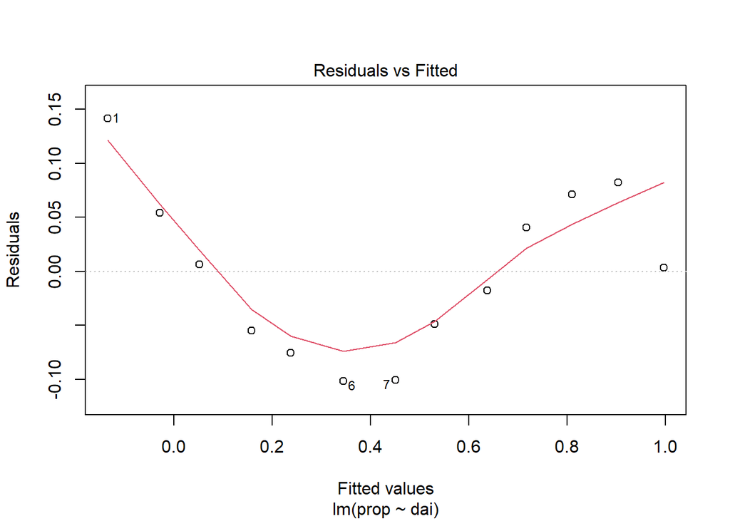

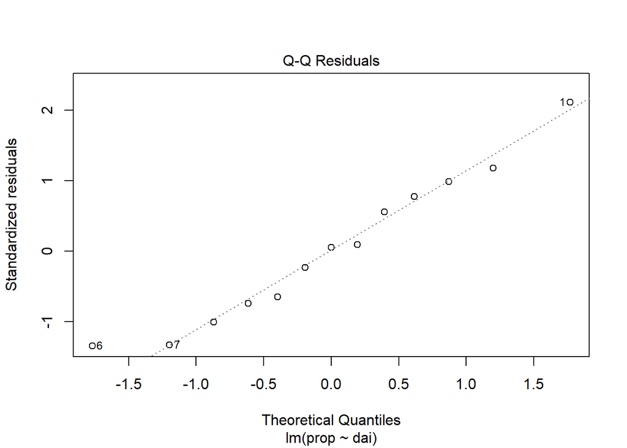

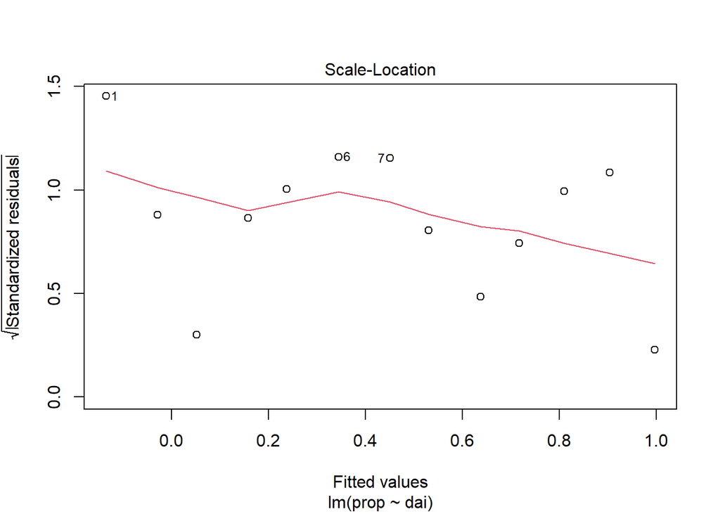

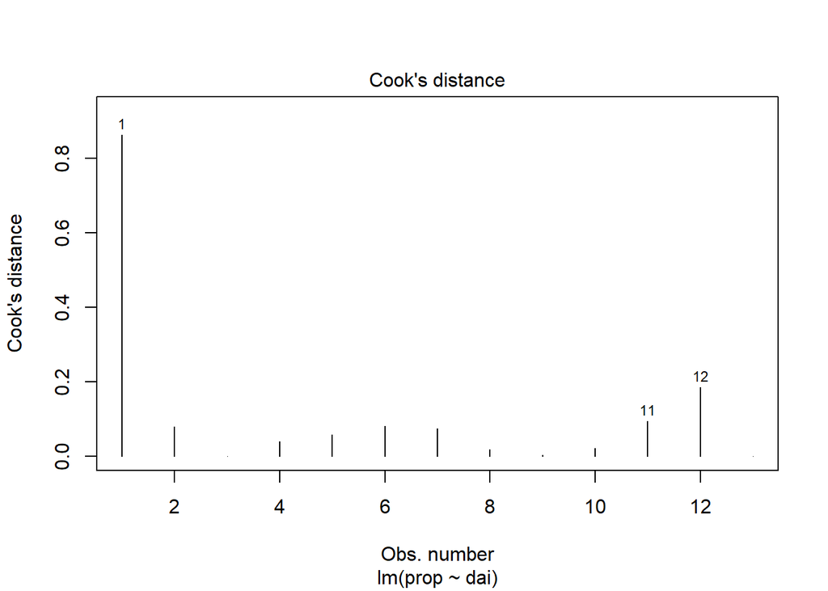

```r
# A plot of residuals vs. fitted values
plot(lmod, which=1)

# A normal Q-Q plot
plot(lmod, which=2)

# A scale-location plot of sqrt(residuals) vs. fitted values
plot(lmod, which=3)

# Cook's distances vs. row labels (i.e., row 1, row 2, row 3, etc.)/number of observations (i.e., 1, 2, 3, etc.)
plot(lmod, which=4)
```

A more visually appealing presentation can be created with package `ggresidpanel`:

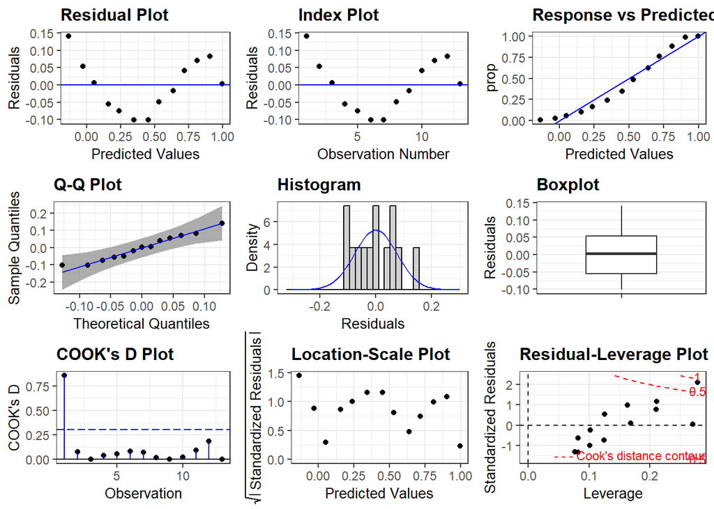

```r
# Create all relevant plots
resid_panel(lmod, qqbands = TRUE, plots = "all")
```

```r
# Optional - learn more about the ggresidpanel by visiting their webpage with the following command:
# browseURL("https://goodekat.github.io/ggResidpanel/")
```

We can also get more information about the `resid_panel()` command by placing our cursor somewhere within the word and pressing ‘F1’.

**Some questions**: > What is represented in each figure above? > How does it provide information on the goodness of fit of our model? > Do you see any problems with the goodness of fit?

**Comparing observed values to predicted**

We can better visualize some of the issues with this fit by plotting the observed values from the data, and comparing them to the line created in the model. We first need to calculate the predicted values. We’ll use the `predict()` command to do so, and store the predicted values in dta under the column name ‘pred’ (for predicted).

```r
# Calculate the predicted values with predict()
dta[,"pred"] <- predict(object = lmod, newdata = dta[,"dai"])

# Display dta as a table with gt::gt()
gt::gt(dta)
```

| dai | prop | pred |
| --- | --- | --- |
| 6 | 0.006420546 | -0.13505081 |
| 14 | 0.025682183 | -0.02855314 |
| 20 | 0.057784912 | 0.05132012 |
| 28 | 0.102728732 | 0.15781779 |
| 34 | 0.162118780 | 0.23769105 |
| 42 | 0.242375602 | 0.34418872 |
| 50 | 0.349919743 | 0.45068639 |
| 56 | 0.481540931 | 0.53055965 |
| 64 | 0.619582665 | 0.63705732 |
| 70 | 0.757624398 | 0.71693058 |
| 77 | 0.881219904 | 0.81011604 |
| 84 | 0.985553772 | 0.90330150 |
| 91 | 1.000000000 | 0.99648697 |

**Challenge**: Why was `dta[ , "dai"]` used? Can `dta$dai` be used? (Hint:`predict()` and F1)

To visualize the differences between the observed and predicted values, we’ll want to transform our data to have a single column for x and for y, and to have predicted or observed as a variable to color points by. To do this, we’ll ‘melt’ the data into a long format. Basically, we’ll reduce the number of columns and add more rows.

```r
# Create dta_long by
dta_long <-

  # Concatenating columns prop and pre
dta %>%
  pivot_longer(cols = c("prop", "pred"),

               # And turning these column names into values in column 'origin'
               names_to = "origin",

               # And putting their values in column 'prop'
               values_to = "prop"
               )
```

**Challenge**: Add comments after each argument of the function `pivot_longer()` which explain what each line accomplishes.

Finally, the data is ready for visualization.

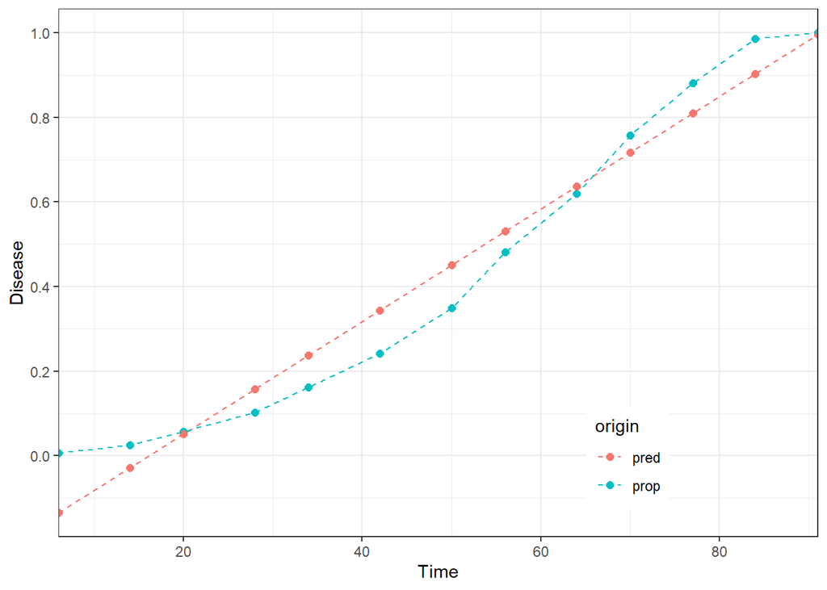

```r
# Use dta_long to create a plot with x = dai, y = proportion of disease, and
# color = predicted or observed.
ggplot(dta_long, aes(dai, prop, color = origin)) +
  geom_point(size = 2) +
  geom_line(linetype = "dashed") +
  theme_bw() +

  # Place the legend inside the graph to save space
  theme(legend.position = c(0.75, 0.15)) + #legend into a plotting area

  # Format the y axis
  scale_y_continuous(
    breaks = seq(0, 1, 0.2),
    name = "Disease"
  ) +

  # Format the x axis
  scale_x_continuous(
    expand = c(0, 0),
    breaks = seq(0, 80, 20),
    name = "Time")
```

**Question:** Identify the areas where the model does not fit as well. > Why do they occur where they do? > Does that mean that representing the data with this model is inappropriate?

**Conclusion**

In statistical terms the linear model does a good job in describing the trend in data in this case. In practical terms, this means that the model told us that the level of disease is growing over time, hence there is a positive relationship between time and the level of disease. The kind of information generated in the creation of the linear model, the slope, y-intercept, and the residual variances are **descriptive statistics**. These values help us understand the relationship between the proportion of disease and time. They can be used to infer the similarities and differences between the disease case in the example data, and another system. This is called **inferential statistics**.

The linear model does a good job, but it could be better. For many instances in the study of plant disease, a more complex model is necessary.